# Exercise 3

### 1. Plot the airquality dataset

1. Load the `airquality` dataset
2. Try to reproduce the plot shown below with `Temperature` on the x-axis and `Ozone` on the y-axis

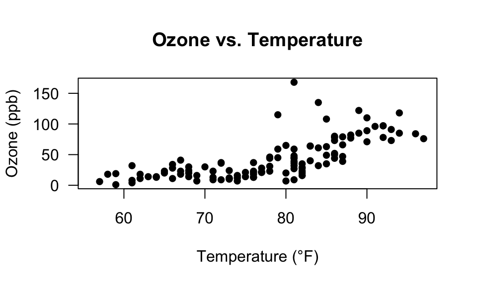

3. Calculate the median ozone concentration and add it to the plot as a line

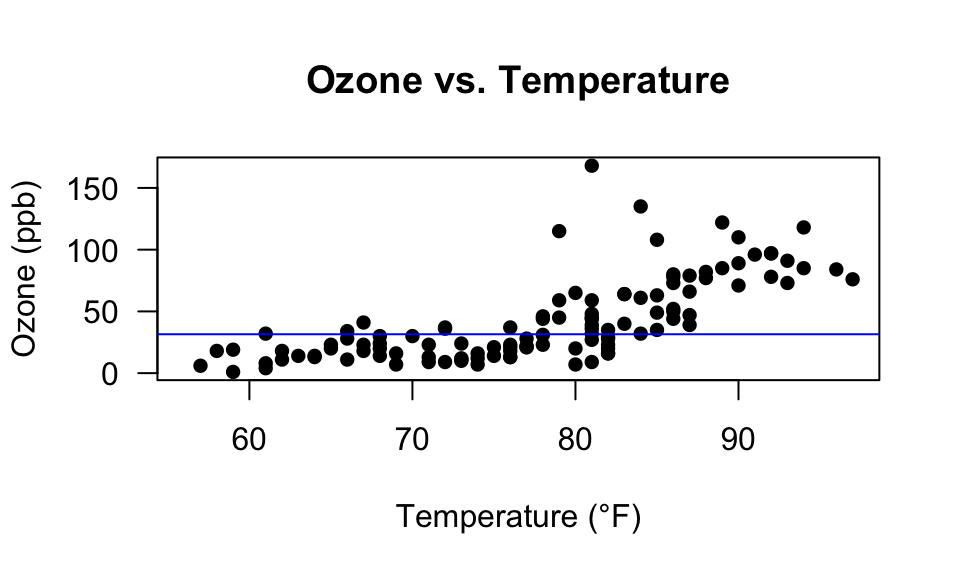

4. Add a second plot on the right with `Temperature` on the x-axis and `Wind` on the y-axis

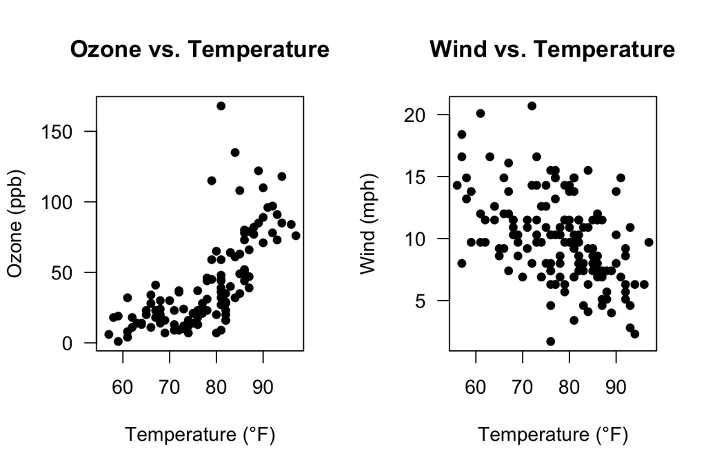

## Hints

### 1. Plot the airquality dataset

1. Load the `airquality` dataset Use the command `data("airquality")` to load the dataset.
2. Try to reproduce the plot shown below with `Temperature` on the x-axis and `Ozone` on the y-axis
   - Axis labels: `xlab = "some text"`, `ylab = "some text"`
   - Title: `main = "some text"`
   - Horizontal axis numbering: `las = 1`
3. Calculate the median ozone concentration and add it to the plot as a line Use the command `median` to calculate the median ($\rightarrow$ Do not forget to remove `NA` values with `na.rm = TRUE`)  
   Use the command `abline` to add a line to an existing plot.
4. Add a second plot on the right with `Temperature` on the x-axis and `Wind` on the y-axis Use the command `par(mfrow = c(1, 2))` to create two plot windows (`c(1, 2)` means 1 row and 2 columns).  
   Alternatively you can use the command `layout(mat = matrix(c(1:2), ncol = 2))`.
5. Save these plots as a PDF Use the following structure:
   1. `pdf(file = "path_to_file/file_name.pdf")`
   2. Code to produce the plots (as many lines of code as needed)
   3. `dev.off()`

Calculate the mean temperature during this month.

Linearly interpolate the Ozone data

Add a linear model to the Temperature data

Introduction to Lists in this exercise: Take two data.frames from a list and add them together. Also add a column and a name as factor. Change location name from character to factor. Introduction to Factors (maybe add a script to Factors that we can have a look at after the exercise or in the solution of the exercise and as a separate script).

Time-series plot of airquality (add year variable convert to datetime object)

ADVANCED Plot Wind against Temperature and do a linear correlation. Add this line to the plot. Point plot add lm as line

Linearly interpolate Ozone values in airquality dataset.

Create a timeseries plot with the airquality dataset. First get an overview of the dataset (try `?airquality`). Plot the temperature for this month in a time series plot. Hints: ?airquality, as.POSIXct (r convert year month day to datetime)

`inline_code` can be displayed this way.